# Comparing species composition survey methods. Part 2b: Community Ordination

Kelly Carscadden

2020-03-04

#### Correspondence Analysis (CA)

How does the vegetation survey method impact our understanding of community composition (and compositional change among sites & treatments)?

- Aggregating subplots within site/treatment levels

I take three ordination approaches:

1. Separate ordinations per survey method
2. Single all-inclusive ordination
3. Site-level ordinations, since among-site variation dwarfs other sources of compositional change

##### 1. Separate Ordinations by Method

CA on plot-level data (*top hits* only)

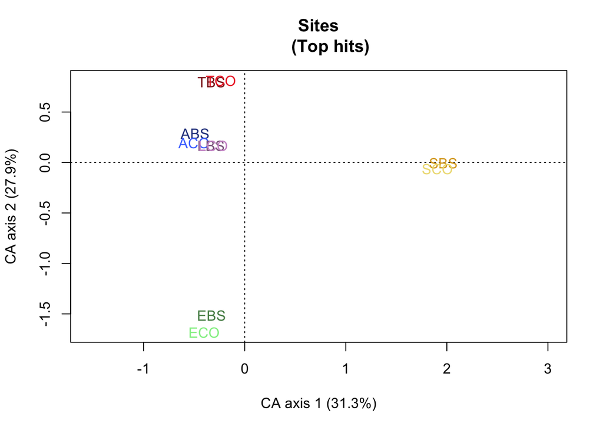

Sites - the major variation in species composition is among sites (black sand and control plots within sites appear very similar at this scale)

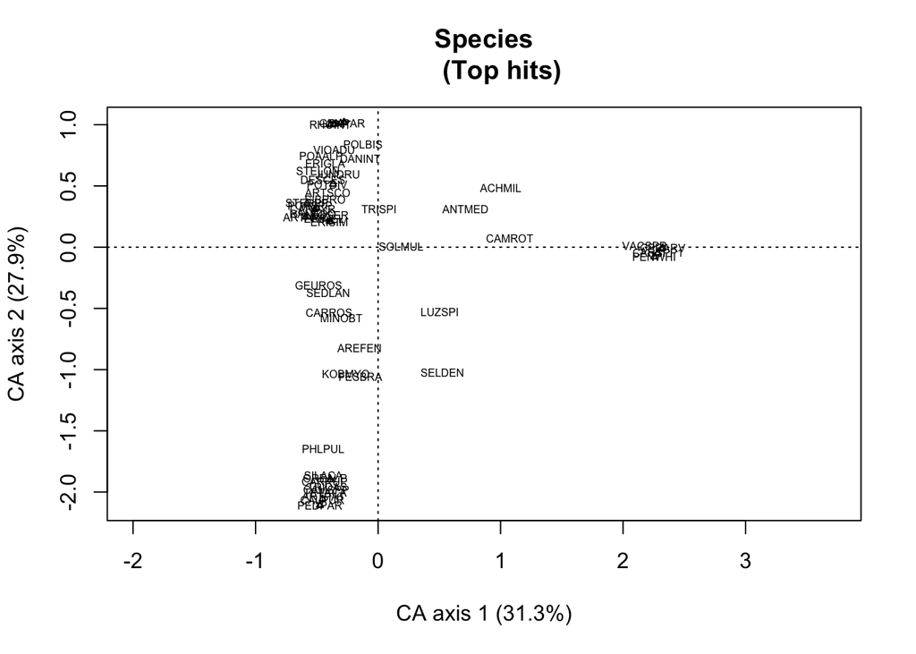

Species - labels are represented as triangles where text is too dense to be legible

CA on plot-level data (*all hits*)

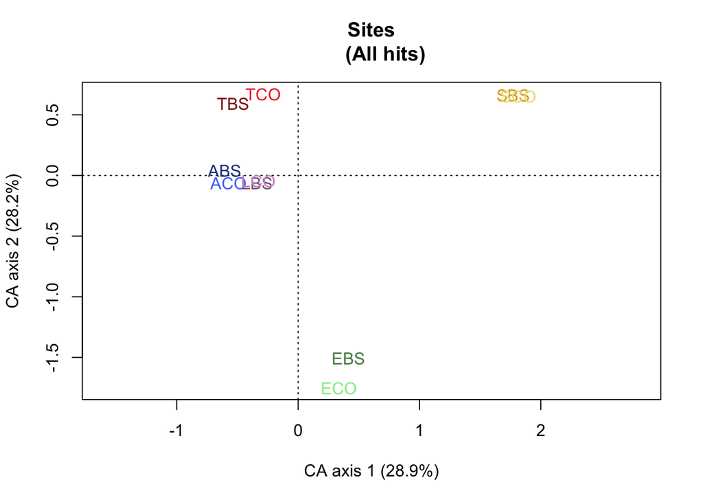

[figure not shown]

The all hits ordination shows a similar general pattern to the top hits ordination, in that among-site variation dominates among-treatment variation in species composition. Different species (compared to the top hits approach) appear to be driving variation among sites.

Which species are driving most of the variation in composition, and do they differ among survey methods?

- Looking at species loadings onto CA axes (*top hits*):

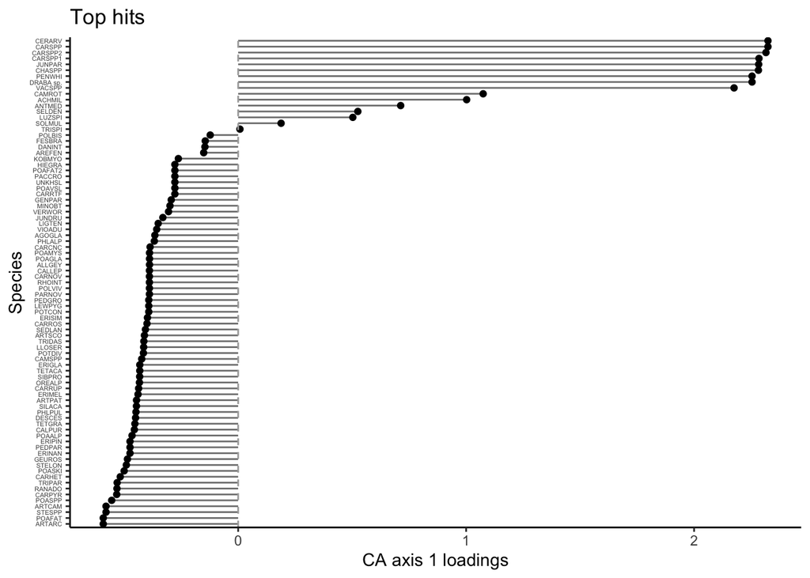

Singling out the species that drive most of the variation (i.e., species that are in the upper quartile of absolute loading, focusing on axis 1 of *top hits*):

```
##  [1] SELDEN    ANTMED    CAMROT    ACHMIL    CARSPP    CARSPP1   CARSPP2
##  [8] CERARV    CHASPP    JUNPAR    VACSPP    DRABA sp. PENWHI
## 83 Levels: ARTARC POAFAT STESPP ARTCAM POASPP CARPYR RANADO ... CERARV
```

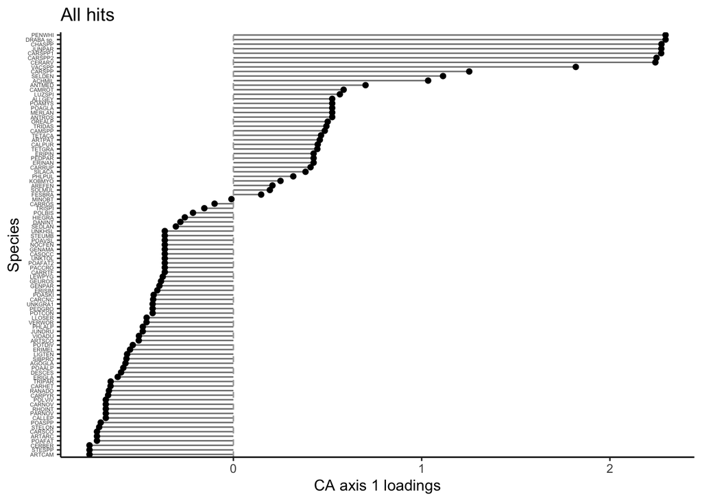

Species that drive most of the variation (i.e., species that are in the upper quartile of absolute loading, focusing on axis 1 of *all hits*):

```
##  [1] SELDEN    CARSPP    ANTMED    ACHMIL    CARSPP1   CARSPP2   CERARV
##  [8] CHASPP    JUNPAR    VACSPP    DRABA sp. PENWHI
## 93 Levels: ARTCAM STESPP CERBER POAFAT ARTARC CARSCO STELON ... PENWHI
```

Which species drive compositional variation along axis 2? Note, species are ordered by their axis 1 scores as above.

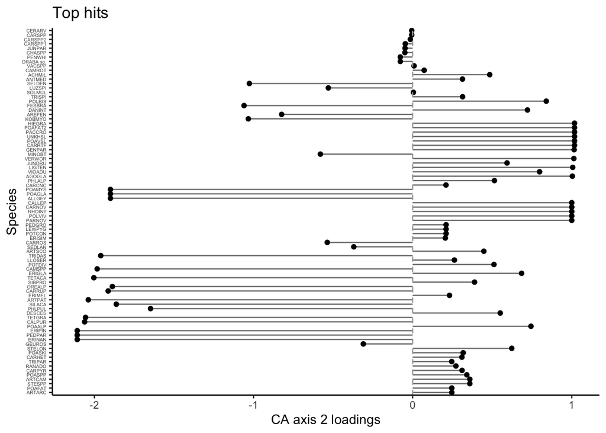

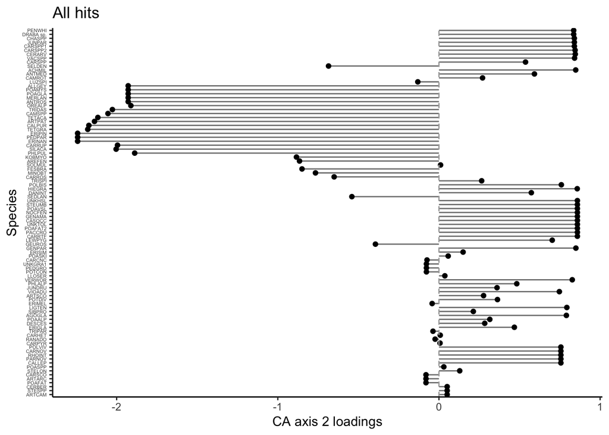

The CA axes are not equivalent (in terms of species loadings) among different ordinations. This reveals which species drive compositional variation within each survey method, but for more direct comparisons of how site, treatment, and method influence community composition, I include both methods within a single ordination below.

##### 2. Single Ordination Comparing Both Methods

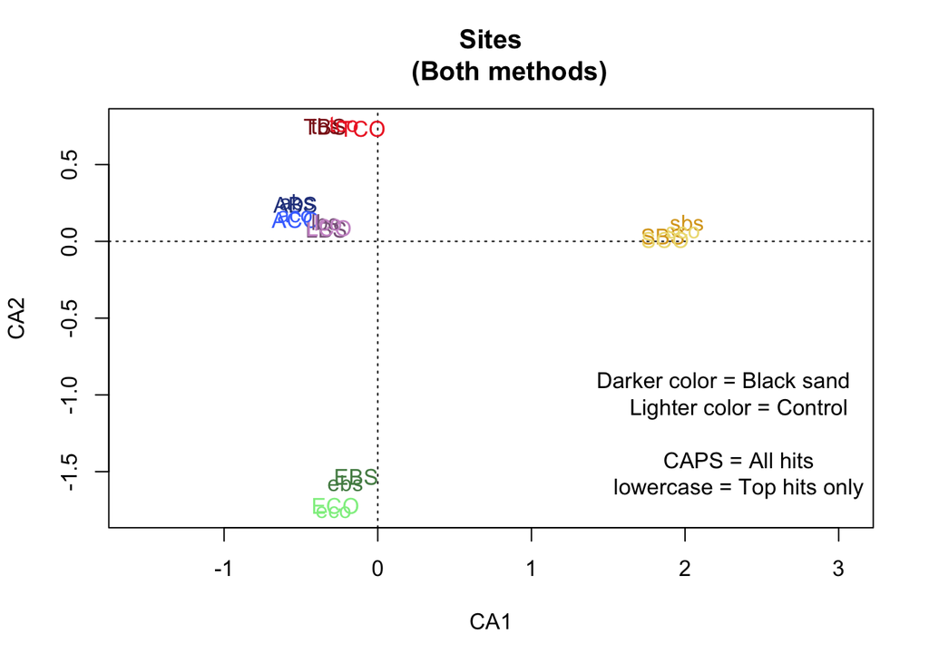

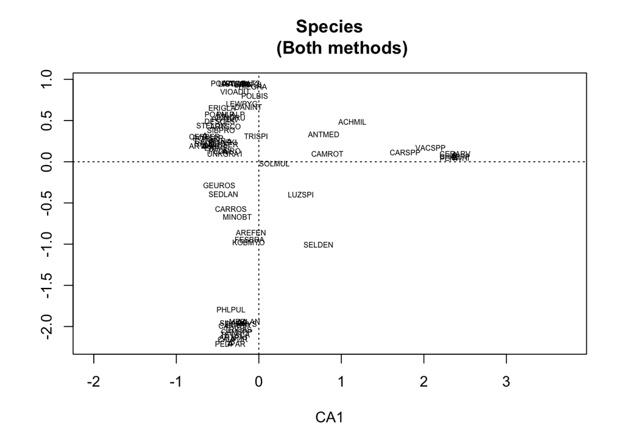

Landscape-scale (among-site) variation dwarfs method or treatment sources of variation in species composition.

Comparing top hits and all hits using a shepard plot (how much of the community composition pattern of interest is preserved in the reduced sampling method?)

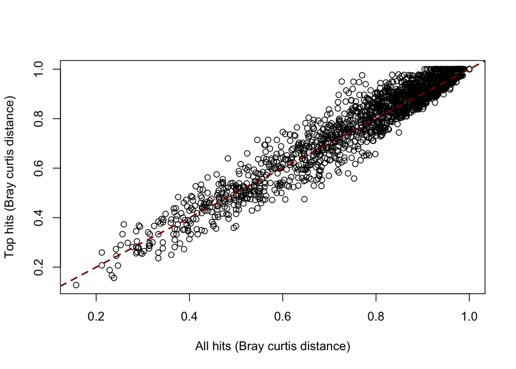

It seems like most of the pattern, in terms of overall dissimilarity among sites, is well preserved using the top hits approach.

##### 3. Site-level Ordination Comparing Both Methods

One CA per site, to focus on variation due to survey method and treatment:

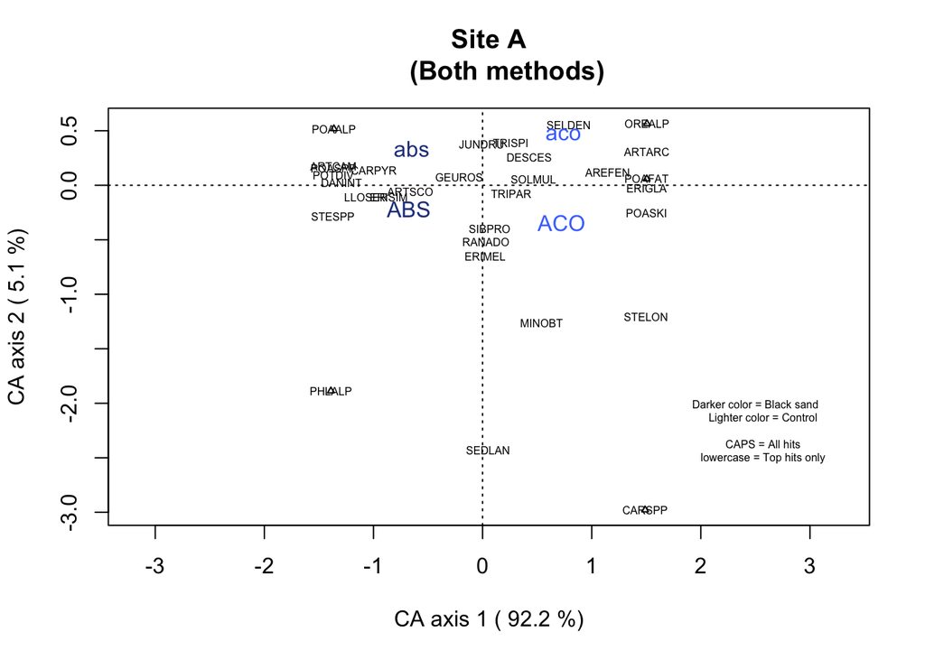

Site A: Control and black sand treatments split along axis 1, which explains nearly all the compositional variation here (vs. split among survey methods is along axis 2, which explains very little variation)

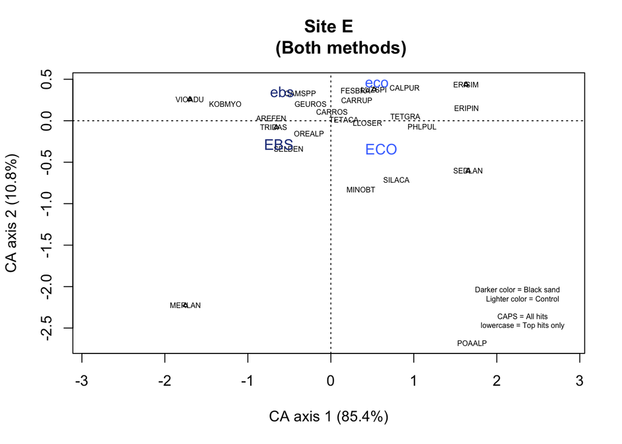

Site E: Similarly, the split among treatments is more important

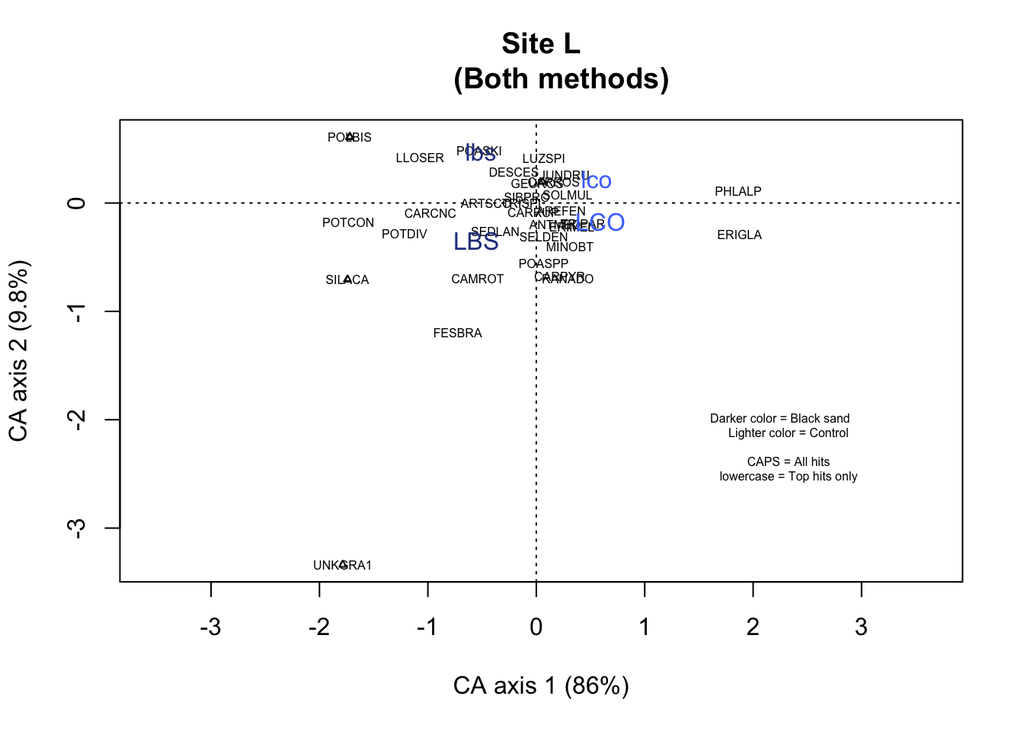

Site L: Similarly, the split among treatments is more important

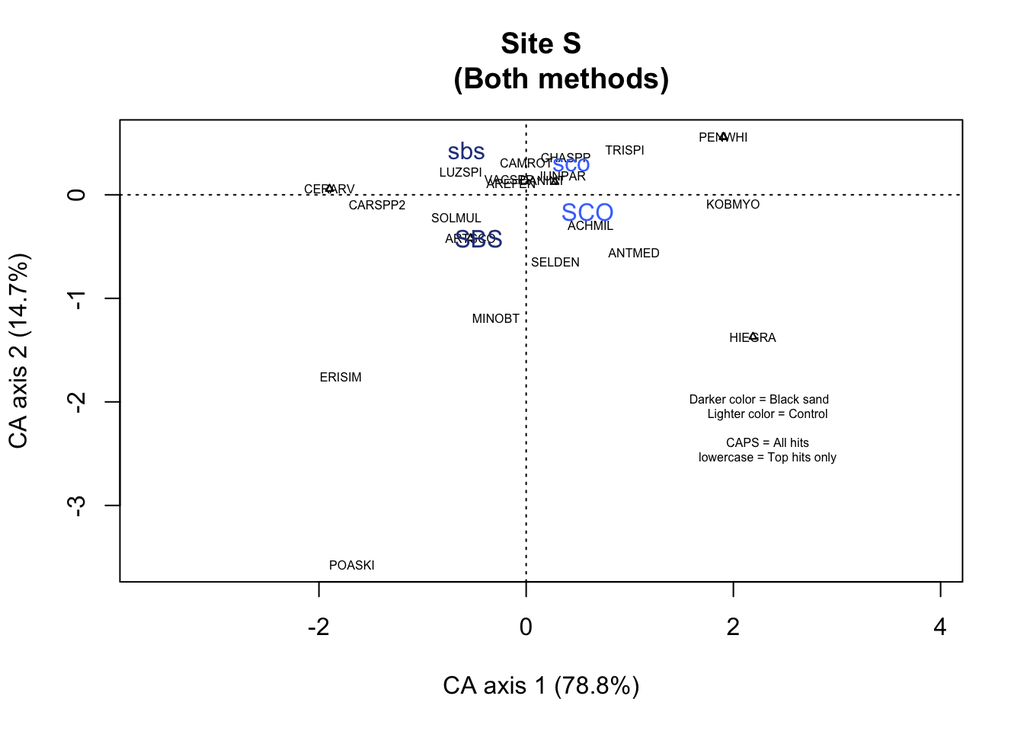

Site S: Similarly, the split among treatments is more important (axis 1 explains more variation)

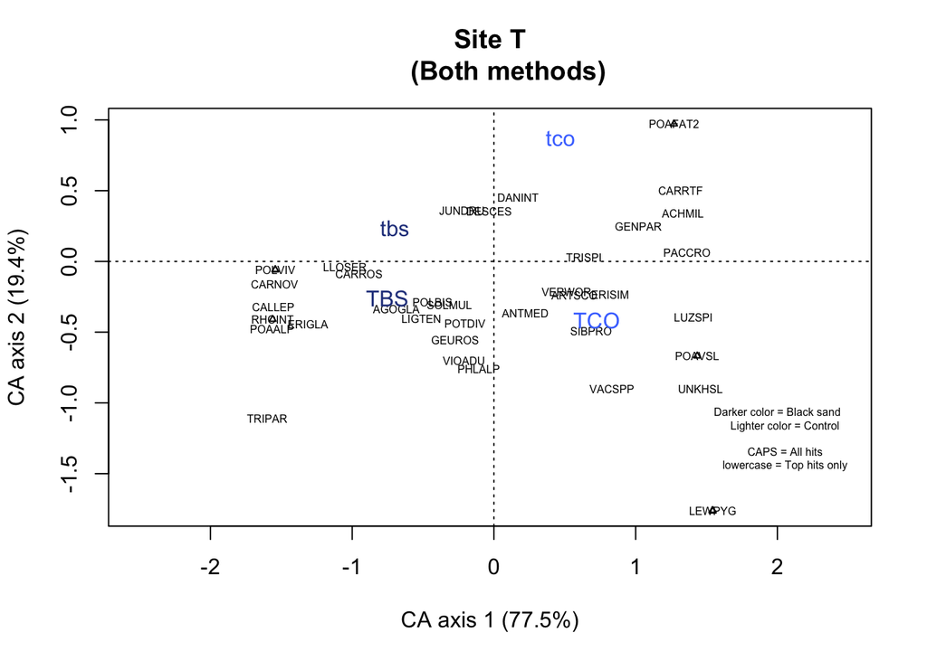

Site T: Similarly, the split among treatments is more important (axis 1 explains more variation). Here, the difference in survey methods was more pronounced in the control treatment.

Ordination reference: http://cc.oulu.fi/~jarioksa/opetus/metodi/notes.pdf